# Fitbit Activity Analysis

### Introduction

It is now possible to collect a large amount of data about personal movement using activity monitoring devices such as a Fitbit, Nike Fuelband, or Jawbone Up. These type of devices are part of the “quantified self” movement – a group of enthusiasts who take measurements about themselves regularly to improve their health, to find patterns in their behavior, or because they are tech geeks. But these data remain under-utilized both because the raw data are hard to obtain and there is a lack of statistical methods and software for processing and interpreting the data.

This project makes use of data from a personal activity monitoring device. This device collects data at 5 minute intervals through out the day. The data consists of two months of data from an anonymous individual collected during the months of October and November, 2012 and include the number of steps taken in 5 minute intervals each day.

The data used in this project can be downloaded from [here](https://d396qusza40orc.cloudfront.net/repdata%2Fdata%2Factivity.zip)

#### Dataset Overview

The variables included in this dataset are:

- **steps**: Number of steps taking in a 5-minute interval (missing values are coded as NA)
- **date**: The date on which the measurement was taken in YYYY-MM-DD format
- **interval**: Identifier for the 5-minute interval in which measurement was taken

The dataset is stored in a comma-separated-value (CSV) file and there are a total of 17,568 observations in this dataset.

### Reading Data and Pre-Processing

Setting the global options for the document.

```r
knitr::opts_chunk$set(warning=FALSE, message = FALSE)
```

Loading the required library for plotting.

```r
library(ggplot2)
```

Reading the CSV file into a dataframe names activity.

```r
activity <- read.csv("~/R Projects/Fitbit-Activity-Analysis/Data/activity.csv", stringsAsFactors=FALSE)
head(activity)
```

|  | steps | date | interval |
| --- | --- | --- | --- |
| 1 | NA | 2012-10-01 | 0 |
| 2 | NA | 2012-10-01 | 5 |
| 3 | NA | 2012-10-01 | 10 |
| 4 | NA | 2012-10-01 | 15 |
| 5 | NA | 2012-10-01 | 20 |
| 6 | NA | 2012-10-01 | 25 |

As we can see steps column does have some missing values, we will be dealing with them later and then comparing our outputs with and without missing values.

exploring the dataframe,

```r
str(activity)
```

```
## 'data.frame':    17568 obs. of  3 variables:
##  $ steps   : int  NA NA NA NA NA NA NA NA NA NA ...
##  $ date    : chr  "2012-10-01" "2012-10-01" "2012-10-01" "2012-10-01" ...
##  $ interval: int  0 5 10 15 20 25 30 35 40 45 ...
```

We have to now convert the date column type to date instead of character before proceeding.

```r
activity$date <- as.Date(activity$date, format = "%Y-%m-%d")
```

We will now try to analyse and try to answer few questions.

### What is mean total number of steps taken per day?

To answer the question we will analyse total steps taken per day. We do that by summing the steps for every single date available to us.

```r
day_wise <- tapply(activity$steps, activity$date, sum, na.rm=TRUE)
head(day_wise)
```

```
## 2012-10-01 2012-10-02 2012-10-03 2012-10-04 2012-10-05 2012-10-06
##          0        126      11352      12116      13294      15420
```

Now we plot a Histogram to analyse frequency of total steps per day.

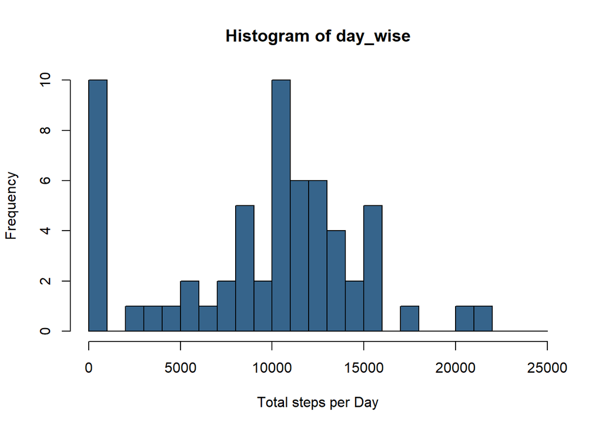

```r
hist(day_wise, xlab = "Total steps per Day", breaks = seq(0,25000, by=1000), col="steelblue4")
```

Clearly from the plot we can see we have many days with 0 total steps which can be the result of missing value too. Apart from that major distribution is between 10,000 to 15,000 steps most being between 10,000-11,000 which was the total for 10 seperate days.

We can now compute the mean and median of total steps per day.

```r
mean(day_wise)
```

```
## [1] 9354.23
```

```r
median(day_wise)
```

```
## [1] 10395
```

This is considered to be a very healthy amount.

### What is the average daily activity pattern?

We will compute the average number of steps taken per interval (0 to 2355) during the day.

```r
interval_wise <- tapply(activity$step, activity$interval, mean, na.rm=TRUE)
```

We will now plot the values obtained to take a closer look at the patterns.

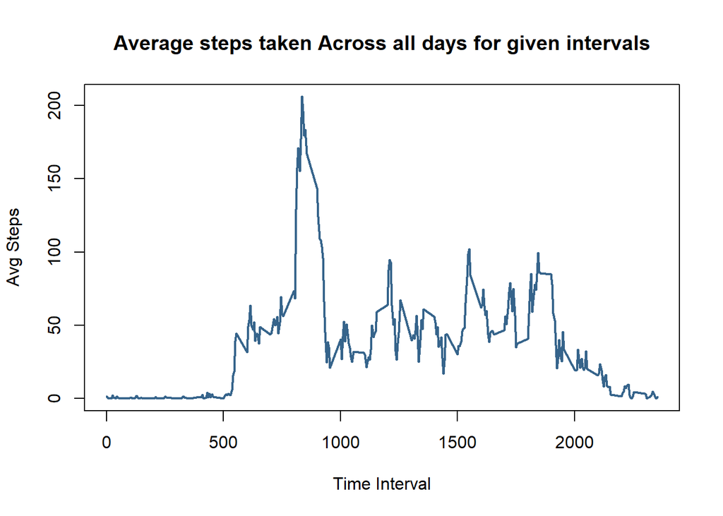

```r
plot(unique(activity$interval) ,interval_wise, type="l", ylab = "Avg Steps",
     xlab = "Time Interval", main = "Average steps taken Across all days for given intervals",
     col="steelblue4", lwd= 2)
```

There is no activity after midnight to 5am which would be the period when subject would be asleep. There is decent average steps from 10 am to 8pm which are the working hours and slowly drissle out when it is time to relax. The maximum activity happen somewhere between 8-10am which would be the time to specifically workout.

There is a very obvious peak, let us find out the time interval at which is happens.

```r
interval_wise[which.max(interval_wise)]
```

```
##      835
## 206.1698
```

8:35- 8:40 am is when subject takes the most number of steps.

### Imputing missing values

Finally as discussed earlier we will impute the missing values and then alltogther see the changes and effect of missing data.

First we will see the number of missing values we are dealing with.

```r
logv <- sapply(activity, is.na)
colSums(as.data.frame(colSums(logv)))
```

```
## colSums(logv)
##          2304
```

So we have 2304 intervals which have no steps recorded.

**Imputing formula:** We will be using the average number of steps in a given interval to impute value for steps missing in that interval.

Now we will create a new dataframe activity_imputed which we contain the imputed data.

```r
interval_df <- aggregate(activity$steps, by=list(activity$interval), FUN=mean, na.rm=TRUE)
names(interval_df) <- c("interval", "mean")
imputed_steps <- interval_df$mean[match(activity$interval, interval_df$interval)]
activity_imputed <- transform(activity, steps = ifelse(is.na(activity$steps),
                    yes = imputed_steps, no = activity$steps))
```

Now we will redo the Analysis that we did while answering the first question and figure out the difference in results thus obtained.

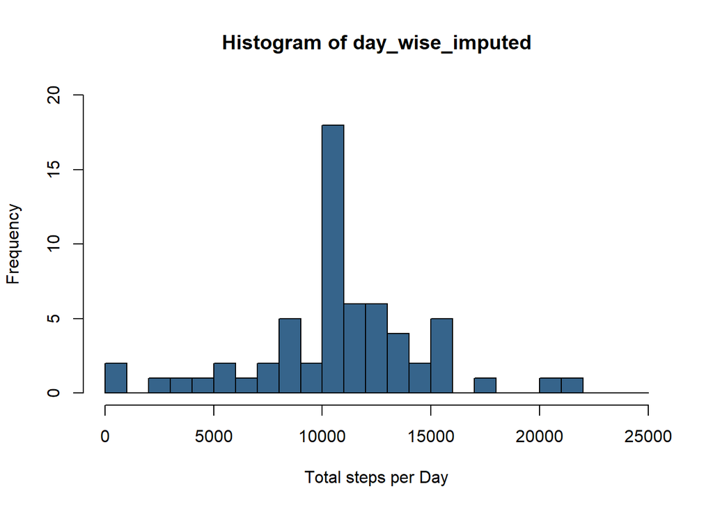

```r
day_wise_imputed <- tapply(activity_imputed$steps, activity_imputed$date, sum, na.rm=TRUE)
hist(day_wise_imputed, xlab = "Total steps per Day", breaks = seq(0,25000, by=1000), col="steelblue4", ylim = c(0,20))
```

```r
mean(day_wise_imputed)
```

```
## [1] 10766.19
```

```r
median(day_wise_imputed)
```

```
## [1] 10766.19
```

- Firstly we observe that the domination interval of 0 total steps has shrunk due to us eliminating missing values.
- While mesian is in the same ballpark as original, mean has had a significant increase due to additional values.
- Mean and Median has coincided, which shows the distribution of total steps is somewhat of a normal distribution.

### Are there differences in activity patterns between weekdays and weekends?

To do this, we have to first figure out which are the weekdays and which are the weekends. We will be adding a column to our imputed data frame which will denote which day it is one of the two.

```r
activity_imputed <- transform(activity_imputed, day = ifelse(weekdays(date) %in% c("Sunday","Saturday"), yes = "Weekend", no = "Weekday"))
head(activity_imputed)
```

|  | steps | date | interval | day |
| --- | --- | --- | --- | --- |
| 1 | 1.7169811 | 2012-10-01 | 0 | Weekday |
| 2 | 0.3396226 | 2012-10-01 | 5 | Weekday |
| 3 | 0.1320755 | 2012-10-01 | 10 | Weekday |
| 4 | 0.1509434 | 2012-10-01 | 15 | Weekday |
| 5 | 0.0754717 | 2012-10-01 | 20 | Weekday |
| 6 | 2.0943396 | 2012-10-01 | 25 | Weekday |

Now finally we will plot interval wise average number of steps for both weekdays and weekends and the compare the result.

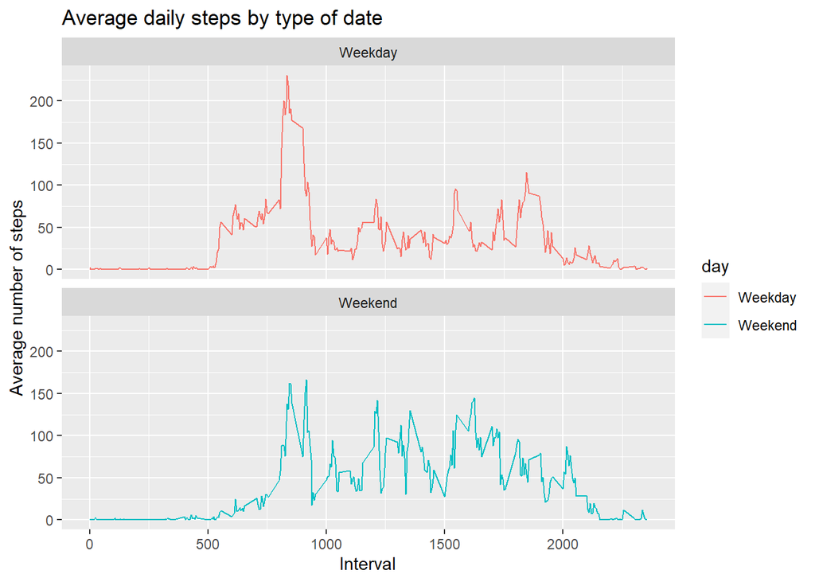

```r
activity_by_date <- aggregate(steps~interval + day, activity_imputed, mean, na.rm = TRUE)

ggplot(activity_by_date, aes(x = interval , y = steps, color = day)) + geom_line() + labs(title = "Average daily steps by type of date", x = "Interval", y = "Average number of steps") + facet_wrap(~day, ncol = 1, nrow=2)
```

Due to obvious reasons, The activity for Weekend is spread out theroughout the day insted of a specific workout period due to the absense of having to work. Also the activity is delayed in the mornign due to a delayed wake up time for the days of holidays.